# 금융공학 네트워킹 논문리딩 발표자료 - Stock fraud detection using peer group analysis

[금융공학 네트워킹 논문리딩](https://www.notion.so/Financial-Engineers-Network-d4981a54bdba4c41b54441d3696b3f04)에서 발표한 자료와 코드 입니다. 코드는 해당 논문을 보면서 직접 만들어 보았습니다.

- 논문 주소 : https://www.sciencedirect.com/science/article/pii/S0957417412002692
- 발표 자료 : https://www2.slideshare.net/ParkJunPyo1/stock-fraud-detection-using-peer-group-analysis  
  by JunPyo Park

# Table of Contents

## Import Modules

```python
import pandas as pd
import matplotlib.pyplot as plt
import numpy as np
%matplotlib inline

plt.rcParams["font.family"] = 'GULIM'
plt.rcParams["axes.grid"] = True
plt.rcParams["figure.figsize"] = (12,6)
plt.rcParams["axes.formatter.useoffset"] = False
plt.rcParams['axes.unicode_minus'] = False
plt.rcParams["axes.formatter.limits"] = -10000, 10000
```

## Read Data

```
# 데이터가 없다면 FinanceDataReader 설치하여 아래 코드를 통해 다운로드 가능
import FinanceDataReader as fdr
stocks = fdr.StockListing('KOSDAQ') # 코스닥
name_code = stocks[['Name','Symbol']]
for name, code in name_code.head().values:
    print(name,code)
df_list = [fdr.DataReader(code, '2016-05-01', '2019-09-30')['Close'] for name, code in name_code.values]
df = pd.concat(df_list, axis=1)
df.columns = name_code['Name']
df = df.dropna(axis=1) # drop nan
```

```python
df = pd.read_pickle('kosdaq.pkl')
```

```python
df.head()
```

| Name Date | 3S | APS홀딩스 | AP위성 | CJ ENM | CJ프레시웨이 | CMG제약 | CNH | CS | CSA 코스믹 | DMS | ... | 휴맥스 | 휴맥스홀딩스 | 휴메딕스 | 휴비츠 | 휴온스글로벌 | 휴젤 | 흥구석유 | 흥국 | 흥국에프엔비 | 희림 |
| --- | --- | --- | --- | --- | --- | --- | --- | --- | --- | --- | --- | --- | --- | --- | --- | --- | --- | --- | --- | --- | --- |
| 2016-05-02 | 4240 | 14044 | 9050 | 196400 | 56500 | 4684 | 1495 | 1690 | 4992 | 9050 | ... | 13200 | 7380 | 44198 | 17500 | 55424 | 102816 | 3255 | 2348 | 5143 | 6010 |
| 2016-05-03 | 4330 | 14007 | 9100 | 196400 | 57300 | 4739 | 1510 | 1690 | 5012 | 9280 | ... | 13200 | 7380 | 47273 | 17800 | 55424 | 110045 | 3420 | 2400 | 5683 | 6760 |
| 2016-05-04 | 4115 | 14268 | 9090 | 196000 | 56100 | 4657 | 1485 | 1700 | 4894 | 9130 | ... | 13450 | 7370 | 47713 | 17350 | 55424 | 108442 | 3355 | 2390 | 5653 | 5800 |
| 2016-05-09 | 4085 | 14119 | 9010 | 198000 | 55600 | 4639 | 1455 | 1720 | 4649 | 9160 | ... | 13550 | 7300 | 47713 | 17200 | 55424 | 108374 | 3320 | 2363 | 5663 | 5560 |
| 2016-05-10 | 4130 | 14342 | 9010 | 199100 | 57100 | 4748 | 1475 | 1750 | 4742 | 9200 | ... | 13750 | 7320 | 48680 | 18000 | 55424 | 108920 | 3445 | 2363 | 5843 | 5690 |

5 rows × 1098 columns

## Preprocessing

논문에서 분석 기간의 종가의 최솟값이 5천원 이상인 종목들을 필터링 하였는데 사실 왜 했는지 모르겠다.... 시가 총액도 아니고 종가를 기준으로?? 일단 비슷하게 만원 이상인 종목들을 날려보자

> classify a company as a global outlier if the minimum daily closing price since 2004 is greater than m=5000

```python
(df.min() >= 10000).sum()
```

```
128
```

```python
df = df[df.columns[df.min() < 10000]]
df.head()
```

| Name Date | 3S | APS홀딩스 | AP위성 | CMG제약 | CNH | CS | CSA 코스믹 | DMS | EG | EMW | ... | 휘닉스소재 | 휴림로봇 | 휴마시스 | 휴맥스 | 휴맥스홀딩스 | 휴비츠 | 흥구석유 | 흥국 | 흥국에프엔비 | 희림 |
| --- | --- | --- | --- | --- | --- | --- | --- | --- | --- | --- | --- | --- | --- | --- | --- | --- | --- | --- | --- | --- | --- |
| 2016-05-02 | 4240 | 14044 | 9050 | 4684 | 1495 | 1690 | 4992 | 9050 | 10300 | 2780 | ... | 1545 | 1065 | 2519 | 13200 | 7380 | 17500 | 3255 | 2348 | 5143 | 6010 |
| 2016-05-03 | 4330 | 14007 | 9100 | 4739 | 1510 | 1690 | 5012 | 9280 | 10350 | 2810 | ... | 1570 | 1095 | 2468 | 13200 | 7380 | 17800 | 3420 | 2400 | 5683 | 6760 |
| 2016-05-04 | 4115 | 14268 | 9090 | 4657 | 1485 | 1700 | 4894 | 9130 | 10350 | 2830 | ... | 1660 | 1063 | 2475 | 13450 | 7370 | 17350 | 3355 | 2390 | 5653 | 5800 |
| 2016-05-09 | 4085 | 14119 | 9010 | 4639 | 1455 | 1720 | 4649 | 9160 | 10200 | 2800 | ... | 1725 | 1019 | 2475 | 13550 | 7300 | 17200 | 3320 | 2363 | 5663 | 5560 |
| 2016-05-10 | 4130 | 14342 | 9010 | 4748 | 1475 | 1750 | 4742 | 9200 | 10250 | 2925 | ... | 1665 | 1023 | 2475 | 13750 | 7320 | 18000 | 3445 | 2363 | 5843 | 5690 |

5 rows × 970 columns

### Train, Test 분리

논문과 같이 40개월 코스닥 데이터를 사용했으며 18개월(2016-05-01 ~ 2017-10-31)을 트레이닝 셋으로 사용

```python
train_df = df[:'2017-10-31']
len(train_df)
```

```
368
```

```python
train_df = train_df.iloc[3:]
len(train_df)
```

```
365
```

11월 부터 테스트 셋

```python
test_df = df['2017-10-31':]
len(test_df)
```

```
470
```

### Smoothing the dataFrame

[figure not shown]

5일씩 Non overlap 하게 짤라서 평균을 내어 smoothing

```python
def smooth_df(df):
    D = len(df) # 365
    N = int(D/5) # 73
    window_length = int(D/N) # 5
    print(D, N, window_length)
    df_smoothed = pd.DataFrame(columns = df.columns, index=range(N))
    for i in range(N):
        start_iloc = i * window_length
        end_iloc = start_iloc + window_length
        y_i = df.iloc[start_iloc:end_iloc].mean(axis=0)
        df_smoothed.iloc[i] = y_i
    return df_smoothed
```

```python
train_df
```

| Name Date | 3S | APS홀딩스 | AP위성 | CMG제약 | CNH | CS | CSA 코스믹 | DMS | EG | EMW | ... | 휘닉스소재 | 휴림로봇 | 휴마시스 | 휴맥스 | 휴맥스홀딩스 | 휴비츠 | 흥구석유 | 흥국 | 흥국에프엔비 | 희림 |
| --- | --- | --- | --- | --- | --- | --- | --- | --- | --- | --- | --- | --- | --- | --- | --- | --- | --- | --- | --- | --- | --- |
| 2016-05-09 | 4085 | 14119 | 9010 | 4639 | 1455 | 1720 | 4649 | 9160 | 10200 | 2800 | ... | 1725 | 1019 | 2475 | 13550 | 7300 | 17200 | 3320 | 2363 | 5663 | 5560 |
| 2016-05-10 | 4130 | 14342 | 9010 | 4748 | 1475 | 1750 | 4742 | 9200 | 10250 | 2925 | ... | 1665 | 1023 | 2475 | 13750 | 7320 | 18000 | 3445 | 2363 | 5843 | 5690 |
| 2016-05-11 | 4220 | 14305 | 8980 | 4676 | 1485 | 1735 | 4796 | 9220 | 10200 | 2900 | ... | 1720 | 1035 | 2475 | 13550 | 7270 | 17900 | 3455 | 2350 | 5843 | 5610 |
| 2016-05-12 | 4175 | 14939 | 9020 | 4684 | 1470 | 1910 | 4757 | 9690 | 10200 | 2915 | ... | 1750 | 1035 | 2475 | 14000 | 7280 | 17650 | 3410 | 2328 | 5763 | 5370 |
| 2016-05-13 | 4040 | 14752 | 8950 | 4540 | 1495 | 1885 | 4674 | 10300 | 10300 | 3200 | ... | 1800 | 1069 | 2475 | 13400 | 7180 | 17650 | 3435 | 2360 | 5713 | 5170 |
| ... | ... | ... | ... | ... | ... | ... | ... | ... | ... | ... | ... | ... | ... | ... | ... | ... | ... | ... | ... | ... | ... |
| 2017-10-25 | 1945 | 10150 | 8030 | 3252 | 1390 | 1420 | 3923 | 8480 | 10000 | 2940 | ... | 924 | 2075 | 1640 | 9340 | 4695 | 13400 | 2790 | 3650 | 1959 | 4655 |
| 2017-10-26 | 1935 | 9820 | 8000 | 3228 | 1385 | 1405 | 4021 | 8310 | 9900 | 2800 | ... | 919 | 2015 | 1640 | 9290 | 4670 | 13300 | 2800 | 3650 | 1951 | 4575 |
| 2017-10-27 | 1955 | 10100 | 7910 | 3290 | 1380 | 1405 | 4115 | 8480 | 10000 | 2795 | ... | 942 | 2025 | 1630 | 9260 | 4685 | 13700 | 2810 | 3675 | 1959 | 4615 |
| 2017-10-30 | 1915 | 10100 | 8020 | 3261 | 1380 | 1435 | 4286 | 8710 | 10400 | 2805 | ... | 956 | 2080 | 1620 | 9360 | 4730 | 13700 | 2815 | 3695 | 1961 | 4610 |
| 2017-10-31 | 1915 | 9970 | 8030 | 3276 | 1390 | 1495 | 4497 | 8760 | 10800 | 2910 | ... | 966 | 2085 | 1620 | 9420 | 4700 | 13650 | 2820 | 3625 | 1965 | 4605 |

365 rows × 970 columns

```python
train_df_smoothed = smooth_df(train_df)
train_df_smoothed
```

```
365 73 5
```

| Name | 3S | APS홀딩스 | AP위성 | CMG제약 | CNH | CS | CSA 코스믹 | DMS | EG | EMW | ... | 휘닉스소재 | 휴림로봇 | 휴마시스 | 휴맥스 | 휴맥스홀딩스 | 휴비츠 | 흥구석유 | 흥국 | 흥국에프엔비 | 희림 |
| --- | --- | --- | --- | --- | --- | --- | --- | --- | --- | --- | --- | --- | --- | --- | --- | --- | --- | --- | --- | --- | --- |
| 0 | 4130 | 14491.4 | 8994 | 4657.4 | 1476 | 1800 | 4723.6 | 9514 | 10230 | 2948 | ... | 1732 | 1036.2 | 2475 | 13650 | 7270 | 17680 | 3413 | 2352.8 | 5765 | 5480 |
| 1 | 3755 | 13895.2 | 7584 | 5003.4 | 1439 | 1769 | 4478.6 | 10050 | 10058 | 3098 | ... | 1830 | 1044 | 2481 | 12740 | 7190 | 16670 | 3368 | 2289.2 | 5305 | 5134 |
| 2 | 3616 | 14007.2 | 7482 | 6183.6 | 1373 | 1885 | 4309.8 | 9900 | 9578 | 3256 | ... | 1606 | 961.6 | 2480.8 | 12230 | 7088 | 16460 | 3248 | 2311.2 | 4855 | 5112 |
| 3 | 3516 | 14551.2 | 7280 | 7133.2 | 1422 | 1852 | 4312.6 | 9984 | 9714 | 3359 | ... | 1466 | 944.8 | 2462 | 12680 | 7122 | 16490 | 3233 | 2324.2 | 4843 | 5228 |
| 4 | 3690 | 13850.6 | 7288 | 7086.6 | 1396 | 1986 | 4509.8 | 9586 | 9754 | 3283 | ... | 1433 | 978 | 2458.4 | 12820 | 7132 | 16890 | 3221 | 2297.2 | 4929 | 5250 |
| ... | ... | ... | ... | ... | ... | ... | ... | ... | ... | ... | ... | ... | ... | ... | ... | ... | ... | ... | ... | ... | ... |
| 68 | 1943 | 9580 | 8140 | 3317.4 | 1414 | 1324 | 3336.6 | 8398 | 12030 | 2231 | ... | 998.2 | 2086 | 2086 | 9708 | 4732 | 12900 | 2669 | 3631 | 1975.4 | 4773 |
| 69 | 1906 | 9534 | 7994 | 3165.4 | 1406 | 1292 | 3599.6 | 8324 | 11080 | 2371 | ... | 957 | 1890 | 1884 | 9284 | 4564 | 12860 | 2649 | 3481 | 1939.4 | 4595 |
| 70 | 1950 | 9552 | 8004 | 3183.2 | 1399 | 1442 | 4076.2 | 8150 | 10640 | 2910 | ... | 927.8 | 2067 | 1834 | 9512 | 4699 | 13010 | 2749 | 3518 | 1913.8 | 4546 |
| 71 | 1914 | 9398 | 7996 | 3156.4 | 1391 | 1437 | 4014.6 | 8110 | 10190 | 2748 | ... | 923 | 2047 | 1623 | 9450 | 4643 | 13410 | 2720 | 3546 | 1917.8 | 4541 |
| 72 | 1933 | 10028 | 7998 | 3261.4 | 1385 | 1432 | 4168.4 | 8548 | 10220 | 2850 | ... | 941.4 | 2056 | 1630 | 9334 | 4696 | 13550 | 2807 | 3659 | 1959 | 4612 |

73 rows × 970 columns

### Normalize

```python
def normalize_df(df):
    return (df - df.mean())/df.std()
```

```python
train_df_normalized = normalize_df(train_df_smoothed)
train_df_normalized
```

| Name | 3S | APS홀딩스 | AP위성 | CMG제약 | CNH | CS | CSA 코스믹 | DMS | EG | EMW | ... | 휘닉스소재 | 휴림로봇 | 휴마시스 | 휴맥스 | 휴맥스홀딩스 | 휴비츠 | 흥구석유 | 흥국 | 흥국에프엔비 | 희림 |
| --- | --- | --- | --- | --- | --- | --- | --- | --- | --- | --- | --- | --- | --- | --- | --- | --- | --- | --- | --- | --- | --- |
| 0 | 2.37126 | -0.223349 | 0.721973 | 1.02083 | -0.30483 | -0.458186 | 0.530776 | 0.0613452 | 0.137598 | 0.221694 | ... | 1.18643 | -1.11287 | -0.02492 | 0.841845 | 0.846127 | 2.79417 | 2.05376 | -1.54273 | 3.32221 | 0.867475 |
| 1 | 1.72743 | -0.382308 | -1.5657 | 1.38439 | -0.716091 | -0.554522 | 0.168019 | 0.589583 | 0.065545 | 0.697778 | ... | 1.53267 | -1.10042 | -0.000303491 | 0.230202 | 0.753371 | 2.05632 | 1.78518 | -1.61336 | 2.77254 | -0.107894 |
| 2 | 1.48878 | -0.352446 | -1.73119 | 2.62448 | -1.44969 | -0.194036 | -0.0819141 | 0.441755 | -0.135532 | 1.19925 | ... | 0.741256 | -1.23199 | -0.00112404 | -0.112587 | 0.635108 | 1.90291 | 1.06895 | -1.58893 | 2.23482 | -0.169911 |
| 3 | 1.31709 | -0.207405 | -2.05892 | 3.62227 | -0.905049 | -0.296588 | -0.0777683 | 0.524539 | -0.0785599 | 1.52616 | ... | 0.246621 | -1.25882 | -0.0782558 | 0.189874 | 0.674529 | 1.92483 | 0.979418 | -1.57449 | 2.22048 | 0.157091 |
| 4 | 1.61583 | -0.394199 | -2.04594 | 3.57331 | -1.19404 | 0.119836 | 0.214215 | 0.132302 | -0.0618035 | 1.28495 | ... | 0.130028 | -1.2058 | -0.0930258 | 0.283973 | 0.686123 | 2.21704 | 0.907796 | -1.60448 | 2.32325 | 0.219108 |
| ... | ... | ... | ... | ... | ... | ... | ... | ... | ... | ... | ... | ... | ... | ... | ... | ... | ... | ... | ... | ... | ... |
| 68 | -1.38358 | -1.53282 | -0.663608 | -0.387173 | -0.993971 | -1.93742 | -1.52288 | -1.03849 | 0.891635 | -2.05399 | ... | -1.40617 | 0.563401 | -1.62089 | -1.80771 | -2.09655 | -0.697817 | -2.38686 | -0.12324 | -1.20612 | -1.12555 |
| 69 | -1.4471 | -1.54509 | -0.900488 | -0.546887 | -1.08289 | -2.03687 | -1.13347 | -1.11142 | 0.493671 | -1.60964 | ... | -1.55173 | 0.250437 | -2.44965 | -2.0927 | -2.29134 | -0.727039 | -2.50623 | -0.289821 | -1.24914 | -1.62733 |
| 70 | -1.37156 | -1.54029 | -0.884263 | -0.528184 | -1.1607 | -1.57072 | -0.427792 | -1.2829 | 0.309351 | 0.101086 | ... | -1.6549 | 0.533063 | -2.65479 | -1.93945 | -2.13481 | -0.617458 | -1.90937 | -0.248731 | -1.27973 | -1.76546 |
| 71 | -1.43337 | -1.58135 | -0.897243 | -0.556344 | -1.24962 | -1.58626 | -0.519 | -1.32232 | 0.120841 | -0.413084 | ... | -1.67186 | 0.501128 | -3.52047 | -1.98112 | -2.19974 | -0.325241 | -2.08246 | -0.217636 | -1.27495 | -1.77955 |
| 72 | -1.40075 | -1.41338 | -0.893998 | -0.446015 | -1.31631 | -1.6018 | -0.291277 | -0.890666 | 0.133408 | -0.0893472 | ... | -1.60685 | 0.515498 | -3.49175 | -2.05909 | -2.13829 | -0.222965 | -1.56319 | -0.0921445 | -1.22572 | -1.5794 |

73 rows × 970 columns

## Target 선정

target1 : 네이처셀  
test period에 주가 조작 이슈 있었음  
https://www.hankyung.com/finance/article/2018061279391

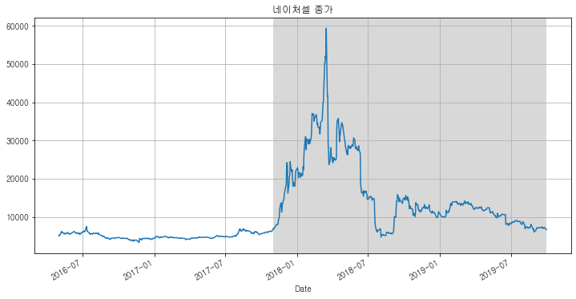

```python
df['네이처셀'].plot(title='네이처셀 종가'); # target1
span_start = test_df.index[0]
span_end = test_df.index[-1]
plt.axvspan(span_start, span_end, facecolor='gray', alpha=0.3);
```

target2 : 제일제강  
test period 에 보물선 관련 주가조작 이슈 있었음  
https://news.joins.com/article/22919304

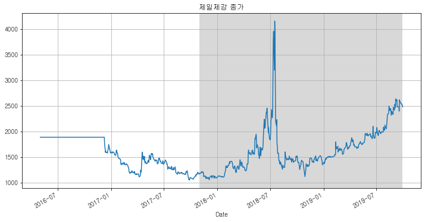

```python
df['제일제강'].plot(title='제일제강 종가'); # target2
span_start = test_df.index[0]
span_end = test_df.index[-1]
plt.axvspan(span_start, span_end, facecolor='gray', alpha=0.3);
```

네이처셀로 진행

```python
target_series = train_df_normalized['네이처셀'] # X_i
```

## Train 기간 동안 Peer Group 선정

```python
def calc_euc_dist(series): # Euclidean Distance
    return np.sqrt(((target_series - series) ** 2).sum())
```

```python
dist = train_df_normalized.apply(lambda x : calc_euc_dist(x), axis=0)
dist.head()
```

```
Name
3S        11.700914
APS홀딩스    15.735540
AP위성      14.869663
CMG제약      8.075605
CNH       13.190733
dtype: float64
```

```python
dist_sorted = dist.sort_values()[1:] # 자기 자신 제외
dist_sorted
```

```
Name
엔에스         5.345096
SM C&C      5.412384
스킨앤스킨       5.456172
경남제약        5.711724
시노펙스        5.830698
             ...
케이피엠테크     15.989271
에스에이티      16.016126
코디엠        16.024772
유니온커뮤니티    16.080493
넥스턴        16.278828
Length: 969, dtype: float64
```

```python
dist_sorted.describe()
```

```
count    969.000000
mean      11.942634
std        2.230288
min        5.345096
25%       10.311152
50%       12.077649
75%       13.682500
max       16.278828
dtype: float64
```

### 거리가 가까운 k(=50)개의 peer 선택

```python
k = 50
top_k_peers_distance = dist_sorted.head(k)
top_k_peers_distance
```

```
Name
엔에스           5.345096
SM C&C        5.412384
스킨앤스킨         5.456172
경남제약          5.711724
시노펙스          5.830698
SBI핀테크솔루션즈    5.933813
디티앤씨          6.337951
신성델타테크        6.443471
에프앤리퍼블릭       6.488208
ISC           6.502550
케이엘넷          6.553080
엠케이전자         6.553721
KMH           6.643468
갤럭시아머니트리      6.737118
양지사           6.811462
티사이언티픽        6.858392
피에스텍          6.981878
성창오토텍         6.993433
와이지-원         7.071417
피앤이솔루션        7.086791
엘아이에스         7.117580
넥슨지티          7.223210
테크윙           7.233212
모다이노칩         7.237018
NHN한국사이버결제    7.262490
코웰패션          7.315591
바이오톡스텍        7.338416
매커스           7.350338
원익            7.373758
기가레인          7.376317
엘오티베큠         7.382457
드림시큐리티        7.383900
신라섬유          7.429271
내츄럴엔도텍        7.438572
웰크론한텍         7.560494
알엔투테크놀로지      7.602668
아이톡시          7.615776
아이진           7.623052
유니슨           7.742869
아이에스이커머스      7.787082
멕아이씨에스        7.843576
아이씨케이         7.848960
티에스이          7.854217
에코프로          7.883812
상아프론테크        7.899212
서울제약          7.902802
드림어스컴퍼니       7.929727
나노스           7.932388
이엠텍           7.940515
덕산하이메탈        7.959457
dtype: float64
```

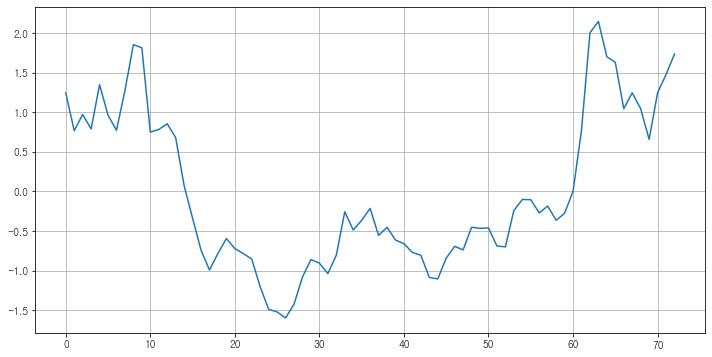

```python
# target
target_series.plot();
```

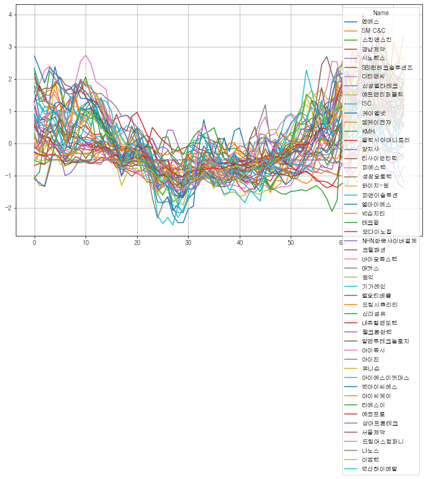

```python
# Peer Group
top_k_peers = top_k_peers_distance.index
train_df_normalized[top_k_peers].plot(figsize=(12,7));
```

## Peer Group Summary 계산

- Simple Mean : 단순 평균
- Weighted Mean : 논문에서 새로 고안한 weight를 부여

[figure not shown]

```python
top_k_values = train_df_normalized[top_k_peers] # y_i_pi(j)
top_k_values
```

| Name | 엔에스 | SM C&C | 스킨앤스킨 | 경남제약 | 시노펙스 | SBI핀테크솔루션즈 | 디티앤씨 | 신성델타테크 | 에프앤리퍼블릭 | ISC | ... | 멕아이씨에스 | 아이씨케이 | 티에스이 | 에코프로 | 상아프론테크 | 서울제약 | 드림어스컴퍼니 | 나노스 | 이엠텍 | 덕산하이메탈 |
| --- | --- | --- | --- | --- | --- | --- | --- | --- | --- | --- | --- | --- | --- | --- | --- | --- | --- | --- | --- | --- | --- |
| 0 | 1.1638 | 0.499601 | 2.33647 | 0.606659 | -0.0447967 | 0.566178 | 1.87953 | 0.708815 | 2.01406 | 0.47472 | ... | 0.919971 | 0.207765 | -0.529407 | -0.258113 | 0.428211 | 2.15948 | 0.0278291 | 1.09631 | -0.612013 | 0.843518 |
| 1 | 0.746059 | 0.491901 | 1.75618 | 0.678126 | 0.168268 | 0.298105 | 1.86334 | 0.200475 | 1.49508 | 0.581346 | ... | 0.456027 | -0.160845 | -0.582433 | -0.338121 | 0.303216 | 1.61916 | -0.21691 | 0.582353 | -0.289835 | 0.628112 |
| 2 | 0.735348 | 0.4688 | 1.29988 | 0.842801 | 0.238655 | 0.138854 | 2.26279 | 0.140671 | 1.12927 | 0.532779 | ... | 0.331757 | 0.143191 | -0.635459 | -0.403717 | 0.460352 | 1.71422 | 0.0305893 | -0.484939 | -0.0345244 | 0.680332 |
| 3 | 0.925472 | 0.535535 | 2.24719 | 0.7246 | 0.187292 | -0.159742 | 2.40314 | -0.0213003 | 1.07871 | 0.769456 | ... | 0.547159 | 1.44274 | -0.530967 | -0.338121 | 0.528207 | 1.70922 | 0.0131079 | -0.512314 | -0.156101 | 0.755398 |
| 4 | 0.992417 | 0.584303 | 2.00416 | 0.822233 | 0.0712474 | 0.067191 | 2.02528 | -0.111007 | 1.2066 | 0.943379 | ... | 1.24515 | 1.90014 | -0.503674 | -0.352534 | 0.228219 | 1.80927 | -0.0899403 | -0.512314 | -0.271599 | 0.314794 |
| ... | ... | ... | ... | ... | ... | ... | ... | ... | ... | ... | ... | ... | ... | ... | ... | ... | ... | ... | ... | ... | ... |
| 68 | 1.43693 | 1.01552 | 0.922936 | 0.557712 | 3.54686 | 1.8163 | 0.71355 | 2.74218 | 0.913652 | 1.17304 | ... | -0.612699 | 2.20687 | 2.19754 | 2.42985 | 1.53531 | -0.171881 | 1.42174 | 2.62497 | 1.14477 | 0.301739 |
| 69 | 1.00045 | 1.19262 | 1.00229 | 0.83473 | 1.75674 | 1.63316 | 0.400462 | 1.48628 | 0.637063 | 1.04183 | ... | -0.894379 | 2.13153 | 2.12346 | 2.31981 | 1.14247 | -0.557106 | 1.05003 | 1.90217 | 1.72833 | 0.0504314 |
| 70 | 0.949572 | 1.38256 | 0.466638 | 1.62842 | 1.7225 | 1.89593 | 0.146753 | 1.44391 | 0.641524 | 0.774403 | ... | -0.873667 | 2.13153 | 1.51912 | 1.94271 | 0.856764 | -0.617141 | 0.902819 | 1.91139 | 1.96541 | 0.347431 |
| 71 | 1.45836 | 1.14642 | 0.759264 | 2.07467 | 1.48661 | 1.76587 | 0.0441902 | 1.53861 | 0.651934 | 0.217648 | ... | -1.25891 | 2.50821 | 1.46843 | 1.84341 | 0.531778 | -0.417024 | 0.678321 | 2.04058 | 2.12346 | 0.758661 |
| 72 | 1.14505 | 1.36459 | 0.511276 | 1.9553 | 1.90322 | 1.66236 | -0.128548 | 1.99462 | 1.15307 | 0.0135343 | ... | -1.36868 | 3.35575 | 1.88952 | 1.46631 | 0.546063 | -0.311963 | 0.860495 | 1.89601 | 2.25111 | 0.569365 |

73 rows × 50 columns

```python
gamma = 10
prox = np.exp(-gamma * top_k_peers_distance)
weight = prox / prox.sum()
weight
```

```
Name
엔에스           5.331122e-01
SM C&C        2.720142e-01
스킨앤스킨         1.755595e-01
경남제약          1.363243e-02
시노펙스          4.148387e-03
SBI핀테크솔루션즈    1.479296e-03
디티앤씨          2.599598e-05
신성델타테크        9.049787e-06
에프앤리퍼블릭       5.785590e-06
ISC           5.012600e-06
케이엘넷          3.024225e-06
엠케이전자         3.004889e-06
KMH           1.224785e-06
갤럭시아머니트리      4.801143e-07
양지사           2.282832e-07
티사이언티픽        1.427776e-07
피에스텍          4.153041e-08
성창오토텍         3.699843e-08
와이지-원         1.696295e-08
피앤이솔루션        1.454563e-08
엘아이에스         1.069106e-08
넥슨지티          3.717686e-09
테크윙           3.363853e-09
모다이노칩         3.238234e-09
NHN한국사이버결제    2.510049e-09
코웰패션          1.475934e-09
바이오톡스텍        1.174742e-09
매커스           1.042711e-09
원익            8.249954e-10
기가레인          8.041529e-10
엘오티베큠         7.562650e-10
드림시큐리티        7.454261e-10
신라섬유          4.735449e-10
내츄럴엔도텍        4.314878e-10
웰크론한텍         1.274881e-10
알엔투테크놀로지      8.361954e-11
아이톡시          7.334699e-11
아이진           6.819975e-11
유니슨           2.057899e-11
아이에스이커머스      1.322538e-11
멕아이씨에스        7.517253e-12
아이씨케이         7.123198e-12
티에스이          6.758446e-12
에코프로          5.027085e-12
상아프론테크        4.309571e-12
서울제약          4.157614e-12
드림어스컴퍼니       3.176232e-12
나노스           3.092814e-12
이엠텍           2.851411e-12
덕산하이메탈        2.359368e-12
dtype: float64
```

```python
p_i_simplemean = top_k_values.apply(lambda x : x.mean(), axis=1) # simple mean
```

```python
p_i_weighted = top_k_values.apply(lambda x : x.dot(weight.T), axis=1) # weighted mean
p_i_weighted
```

```
0     1.175515
1     0.850294
2     0.760501
3     1.044063
4     1.051533
        ...
68    1.229379
69    1.054846
70    0.996407
71    1.259691
72    1.108425
Length: 73, dtype: float64
```

### Peer group summary plot

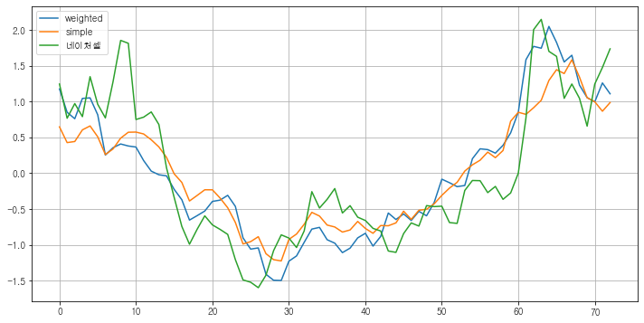

```python
p_i_weighted.plot(label='weighted');
p_i_simplemean.plot(label='simple');
target_series.plot();
plt.legend();
```

Peer group updates

```python
weight
```

```
Name
엔에스           5.331122e-01
SM C&C        2.720142e-01
스킨앤스킨         1.755595e-01
경남제약          1.363243e-02
시노펙스          4.148387e-03
SBI핀테크솔루션즈    1.479296e-03
디티앤씨          2.599598e-05
신성델타테크        9.049787e-06
에프앤리퍼블릭       5.785590e-06
ISC           5.012600e-06
케이엘넷          3.024225e-06
엠케이전자         3.004889e-06
KMH           1.224785e-06
갤럭시아머니트리      4.801143e-07
양지사           2.282832e-07
티사이언티픽        1.427776e-07
피에스텍          4.153041e-08
성창오토텍         3.699843e-08
와이지-원         1.696295e-08
피앤이솔루션        1.454563e-08
엘아이에스         1.069106e-08
넥슨지티          3.717686e-09
테크윙           3.363853e-09
모다이노칩         3.238234e-09
NHN한국사이버결제    2.510049e-09
코웰패션          1.475934e-09
바이오톡스텍        1.174742e-09
매커스           1.042711e-09
원익            8.249954e-10
기가레인          8.041529e-10
엘오티베큠         7.562650e-10
드림시큐리티        7.454261e-10
신라섬유          4.735449e-10
내츄럴엔도텍        4.314878e-10
웰크론한텍         1.274881e-10
알엔투테크놀로지      8.361954e-11
아이톡시          7.334699e-11
아이진           6.819975e-11
유니슨           2.057899e-11
아이에스이커머스      1.322538e-11
멕아이씨에스        7.517253e-12
아이씨케이         7.123198e-12
티에스이          6.758446e-12
에코프로          5.027085e-12
상아프론테크        4.309571e-12
서울제약          4.157614e-12
드림어스컴퍼니       3.176232e-12
나노스           3.092814e-12
이엠텍           2.851411e-12
덕산하이메탈        2.359368e-12
dtype: float64
```

## Peer Group Summary Update

테스트 기간을 돌면서 대푯값을 업데이트 해줘야 함

### Test Set Smoothing and Normalizing

```python
len(test_df)
```

```
470
```

```python
test_df_smoothed = smooth_df(test_df) # smoothing
test_df_smoothed
```

```
470 94 5
```

| Name | 3S | APS홀딩스 | AP위성 | CMG제약 | CNH | CS | CSA 코스믹 | DMS | EG | EMW | ... | 휘닉스소재 | 휴림로봇 | 휴마시스 | 휴맥스 | 휴맥스홀딩스 | 휴비츠 | 흥구석유 | 흥국 | 흥국에프엔비 | 희림 |
| --- | --- | --- | --- | --- | --- | --- | --- | --- | --- | --- | --- | --- | --- | --- | --- | --- | --- | --- | --- | --- | --- |
| 0 | 1952 | 10030 | 7996 | 3722.2 | 1418 | 1450 | 4589.2 | 8626 | 10830 | 2765 | ... | 970.6 | 2107 | 1718 | 9304 | 4668 | 13400 | 2824 | 3624 | 1934.6 | 4620 |
| 1 | 2010 | 10310 | 7856 | 5292.6 | 1413 | 1439 | 4627.6 | 8428 | 10600 | 2652 | ... | 959.8 | 2161 | 1828 | 9268 | 4639 | 13940 | 2829 | 3567 | 1988.2 | 4654 |
| 2 | 1934 | 9800 | 7640 | 6162.4 | 1393 | 1498 | 4091 | 8308 | 12270 | 2633 | ... | 992.4 | 2057 | 2085 | 9246 | 4693 | 13920 | 2759 | 3631 | 2037 | 4825 |
| 3 | 1909 | 9060 | 7632 | 6469.4 | 1384 | 1706 | 3981.2 | 8160 | 13890 | 2882 | ... | 959.8 | 2015 | 2511 | 9064 | 4846 | 13770 | 2751 | 3718 | 2057 | 4769 |
| 4 | 1876 | 8818 | 7740 | 7760.6 | 1376 | 1740 | 4131.2 | 7216 | 12780 | 2881 | ... | 926.4 | 2193 | 2405 | 9340 | 4885 | 14030 | 2740 | 3604 | 2008.2 | 4673 |
| ... | ... | ... | ... | ... | ... | ... | ... | ... | ... | ... | ... | ... | ... | ... | ... | ... | ... | ... | ... | ... | ... |
| 89 | 3089 | 8936 | 7202 | 2741 | 1386 | 3013 | 4090 | 4776 | 9302 | 2780 | ... | 625.6 | 846.4 | 1421 | 5230 | 3306 | 9238 | 4923 | 4491 | 1823.8 | 4243 |
| 90 | 3125 | 9890 | 7116 | 2882 | 1442 | 3395 | 4090 | 5012 | 9218 | 2780 | ... | 649 | 880.2 | 1479 | 5694 | 3587 | 9358 | 5068 | 4705 | 1830.6 | 4377 |
| 91 | 3071 | 11060 | 7084 | 2876 | 1475 | 3507 | 4090 | 5208 | 9608 | 2780 | ... | 693.6 | 892.4 | 1479 | 5544 | 3532 | 9510 | 5313 | 4921 | 1763.4 | 4464 |
| 92 | 3444 | 10230 | 7018 | 2953 | 1541 | 3522 | 4090 | 5324 | 9782 | 2780 | ... | 716.4 | 926.6 | 1537 | 5526 | 3502 | 9516 | 7444 | 5032 | 1752.2 | 4601 |
| 93 | 3620 | 9778 | 6704 | 2809 | 1495 | 3361 | 4090 | 5354 | 9628 | 2780 | ... | 718.2 | 910 | 1486 | 5350 | 3388 | 9196 | 6558 | 4910 | 1725.4 | 4511 |

94 rows × 970 columns

```python
# train set 의 mean 과 std 사용하여 normalize
mean = train_df_smoothed.mean()
std = train_df_smoothed.std()
```

```python
test_df_normalized = (test_df_smoothed - mean)/std
test_df_normalized
```

| Name | 3S | APS홀딩스 | AP위성 | CMG제약 | CNH | CS | CSA 코스믹 | DMS | EG | EMW | ... | 휘닉스소재 | 휴림로봇 | 휴마시스 | 휴맥스 | 휴맥스홀딩스 | 휴비츠 | 흥구석유 | 흥국 | 흥국에프엔비 | 희림 |
| --- | --- | --- | --- | --- | --- | --- | --- | --- | --- | --- | --- | --- | --- | --- | --- | --- | --- | --- | --- | --- | --- |
| 0 | -1.36813 | -1.41284 | -0.897243 | 0.0381695 | -0.94951 | -1.54586 | 0.331778 | -0.813795 | 0.388943 | -0.359128 | ... | -1.50368 | 0.596933 | -3.13071 | -2.07926 | -2.17076 | -0.332546 | -1.46173 | -0.131013 | -1.25487 | -1.55685 |
| 1 | -1.26855 | -1.33819 | -1.12439 | 1.68826 | -1.00509 | -1.58004 | 0.388635 | -1.00893 | 0.292594 | -0.717778 | ... | -1.54184 | 0.683158 | -2.6794 | -2.10345 | -2.20438 | 0.0619459 | -1.43189 | -0.194314 | -1.19083 | -1.46101 |
| 2 | -1.39903 | -1.47417 | -1.47484 | 2.60221 | -1.22739 | -1.39669 | -0.405879 | -1.12719 | 0.992173 | -0.778082 | ... | -1.42666 | 0.517095 | -1.62499 | -2.11824 | -2.14177 | 0.0473351 | -1.84969 | -0.12324 | -1.13251 | -0.97896 |
| 3 | -1.44195 | -1.67146 | -1.48782 | 2.92478 | -1.32743 | -0.750304 | -0.568454 | -1.27305 | 1.67081 | 0.0122173 | ... | -1.54184 | 0.450031 | 0.122779 | -2.24057 | -1.96438 | -0.0622461 | -1.89743 | -0.0266226 | -1.10861 | -1.13682 |
| 4 | -1.49861 | -1.73599 | -1.31259 | 4.28151 | -1.41635 | -0.644644 | -0.346357 | -2.20338 | 1.20582 | 0.00904342 | ... | -1.65985 | 0.734254 | -0.312113 | -2.05506 | -1.91916 | 0.127695 | -1.96309 | -0.153224 | -1.16693 | -1.40745 |
| ... | ... | ... | ... | ... | ... | ... | ... | ... | ... | ... | ... | ... | ... | ... | ... | ... | ... | ... | ... | ... | ... |
| 89 | 0.583978 | -1.70452 | -2.18548 | -0.992825 | -1.3052 | 3.31138 | -0.40736 | -4.60804 | -0.251151 | -0.31152 | ... | -2.72261 | -1.41594 | -4.34922 | -4.81753 | -3.74993 | -3.37306 | 11.0663 | 0.831826 | -1.38727 | -2.61961 |
| 90 | 0.645786 | -1.45017 | -2.32501 | -0.844669 | -0.682746 | 4.4985 | -0.40736 | -4.37546 | -0.286339 | -0.31152 | ... | -2.63993 | -1.36197 | -4.11126 | -4.50566 | -3.42412 | -3.28539 | 11.9318 | 1.06948 | -1.37915 | -2.24187 |
| 91 | 0.553074 | -1.13823 | -2.37693 | -0.850974 | -0.315945 | 4.84656 | -0.40736 | -4.1823 | -0.122964 | -0.31152 | ... | -2.48235 | -1.34249 | -4.11126 | -4.60648 | -3.48789 | -3.17435 | 13.3941 | 1.30936 | -1.45945 | -1.99661 |
| 92 | 1.19347 | -1.35952 | -2.48401 | -0.770066 | 0.417656 | 4.89317 | -0.40736 | -4.06798 | -0.0500741 | -0.31152 | ... | -2.4018 | -1.28788 | -3.8733 | -4.61858 | -3.52267 | -3.16997 | 26.1131 | 1.43263 | -1.47283 | -1.61041 |
| 93 | 1.49565 | -1.48003 | -2.99346 | -0.921374 | -0.0936415 | 4.39284 | -0.40736 | -4.03841 | -0.114586 | -0.31152 | ... | -2.39544 | -1.31438 | -4.08255 | -4.73688 | -3.65485 | -3.40374 | 20.8249 | 1.29714 | -1.50485 | -1.86412 |

94 rows × 970 columns

```python
test_target_series = test_df_normalized[target_series.name]
test_target_series
```

```
0     2.60303
1     3.82391
2     7.63144
3      10.348
4      15.176
       ...
89    2.38505
90    2.10734
91      2.799
92    2.81996
93    2.59726
Name: 네이처셀, Length: 94, dtype: object
```

```python
test_df_normalized[top_k_peers]
```

| Name | 엔에스 | SM C&C | 스킨앤스킨 | 경남제약 | 시노펙스 | SBI핀테크솔루션즈 | 디티앤씨 | 신성델타테크 | 에프앤리퍼블릭 | ISC | ... | 멕아이씨에스 | 아이씨케이 | 티에스이 | 에코프로 | 상아프론테크 | 서울제약 | 드림어스컴퍼니 | 나노스 | 이엠텍 | 덕산하이메탈 |
| --- | --- | --- | --- | --- | --- | --- | --- | --- | --- | --- | --- | --- | --- | --- | --- | --- | --- | --- | --- | --- | --- |
| 0 | 1.19325 | 1.31839 | 0.42696 | 1.85884 | 2.25136 | 2.10826 | -0.268898 | 2.14662 | 1.58728 | -0.239348 | ... | -1.23198 | 4.31763 | 2.17415 | 1.67298 | 0.64963 | -0.171881 | 1.01691 | 1.95138 | 2.49427 | 0.647695 |
| 1 | 1.51191 | 1.23626 | 0.397202 | 2.51155 | 2.39974 | 2.88329 | -0.342311 | 2.53037 | 2.3427 | -0.450832 | ... | -1.25062 | 2.71001 | 2.10786 | 2.04202 | 0.696057 | 0.248364 | 0.985625 | 2.11747 | 2.04443 | 1.37877 |
| 2 | 1.53066 | 2.05248 | 0.377363 | 2.34127 | 3.05415 | 2.72138 | -0.51289 | 2.797 | 1.96499 | -0.307403 | ... | -1.37903 | 3.98131 | 2.90326 | 2.35335 | 0.828194 | 0.638592 | 0.992986 | 2.38199 | 3.13862 | 0.918584 |
| 3 | 1.48513 | 1.90361 | 0.144254 | 2.53433 | 3.96538 | 4.30858 | -0.56903 | 4.53133 | 1.57985 | -0.0278639 | ... | -1.58201 | 4.997 | 2.90716 | 2.68214 | 1.0889 | 0.438475 | 1.3739 | 2.29279 | 4.13555 | 0.308266 |
| 4 | 1.43426 | 1.64694 | -0.212848 | 2.90898 | 4.80052 | 4.31124 | -0.727733 | 4.92006 | 1.849 | -0.266106 | ... | -1.6835 | 3.84678 | 2.25603 | 2.61504 | 0.796052 | 0.253367 | 1.34077 | 2.05595 | 3.73435 | 0.0895962 |
| ... | ... | ... | ... | ... | ... | ... | ... | ... | ... | ... | ... | ... | ... | ... | ... | ... | ... | ... | ... | ... | ... |
| 89 | -1.50705 | -3.0271 | -4.33937 | 5.90605 | 2.49676 | 7.81742 | -1.40249 | -1.00808 | -1.88466 | -3.08805 | ... | -3.37047 | -2.76533 | -1.3287 | 0.325642 | 1.42103 | -2.68635 | 0.472224 | 4.90104 | -1.38524 | -4.55796 |
| 90 | -1.18089 | -2.94497 | -4.08543 | 5.90605 | 2.16575 | 8.33499 | -1.18981 | -0.514689 | -1.77789 | -2.98758 | ... | -3.25552 | -1.62183 | -1.24604 | 0.475943 | 1.53174 | -2.61531 | 0.807131 | 5.13788 | -1.04847 | -4.01292 |
| 91 | -0.646401 | -2.85257 | -4.15982 | 5.90605 | 2.21902 | 7.88378 | -1.2006 | -0.786302 | -1.67825 | -2.90883 | ... | -3.25241 | 0.261576 | -1.20315 | 0.449103 | 1.75315 | -2.53126 | 0.759287 | 5.07329 | -1.11169 | -3.68002 |
| 92 | -0.515188 | -2.63439 | -4.11023 | 5.90605 | 2.21902 | 8.45443 | -1.10128 | -0.661709 | -1.67974 | -2.77706 | ... | -3.23274 | -0.915554 | -1.09398 | 0.475943 | 1.81744 | -2.41719 | 0.900978 | 5.33934 | -1.21503 | -3.5103 |
| 93 | -0.628191 | -2.54712 | -4.22331 | 5.90605 | 2.13151 | 8.3748 | -1.25674 | -0.885977 | -1.80317 | -2.7917 | ... | -3.14989 | -1.73618 | -1.12673 | 0.314907 | 1.33532 | -2.58029 | 1.02979 | 5.1348 | -1.2746 | -3.88563 |

94 rows × 50 columns

### Update Weight

```python
param_lambda = 0.2
T = len(test_df_normalized)
weight_df = pd.DataFrame(columns=top_k_peers, index=range(T))
weight_df
```

| Name | 엔에스 | SM C&C | 스킨앤스킨 | 경남제약 | 시노펙스 | SBI핀테크솔루션즈 | 디티앤씨 | 신성델타테크 | 에프앤리퍼블릭 | ISC | ... | 멕아이씨에스 | 아이씨케이 | 티에스이 | 에코프로 | 상아프론테크 | 서울제약 | 드림어스컴퍼니 | 나노스 | 이엠텍 | 덕산하이메탈 |
| --- | --- | --- | --- | --- | --- | --- | --- | --- | --- | --- | --- | --- | --- | --- | --- | --- | --- | --- | --- | --- | --- |
| 0 | NaN | NaN | NaN | NaN | NaN | NaN | NaN | NaN | NaN | NaN | ... | NaN | NaN | NaN | NaN | NaN | NaN | NaN | NaN | NaN | NaN |
| 1 | NaN | NaN | NaN | NaN | NaN | NaN | NaN | NaN | NaN | NaN | ... | NaN | NaN | NaN | NaN | NaN | NaN | NaN | NaN | NaN | NaN |
| 2 | NaN | NaN | NaN | NaN | NaN | NaN | NaN | NaN | NaN | NaN | ... | NaN | NaN | NaN | NaN | NaN | NaN | NaN | NaN | NaN | NaN |
| 3 | NaN | NaN | NaN | NaN | NaN | NaN | NaN | NaN | NaN | NaN | ... | NaN | NaN | NaN | NaN | NaN | NaN | NaN | NaN | NaN | NaN |
| 4 | NaN | NaN | NaN | NaN | NaN | NaN | NaN | NaN | NaN | NaN | ... | NaN | NaN | NaN | NaN | NaN | NaN | NaN | NaN | NaN | NaN |
| ... | ... | ... | ... | ... | ... | ... | ... | ... | ... | ... | ... | ... | ... | ... | ... | ... | ... | ... | ... | ... | ... |
| 89 | NaN | NaN | NaN | NaN | NaN | NaN | NaN | NaN | NaN | NaN | ... | NaN | NaN | NaN | NaN | NaN | NaN | NaN | NaN | NaN | NaN |
| 90 | NaN | NaN | NaN | NaN | NaN | NaN | NaN | NaN | NaN | NaN | ... | NaN | NaN | NaN | NaN | NaN | NaN | NaN | NaN | NaN | NaN |
| 91 | NaN | NaN | NaN | NaN | NaN | NaN | NaN | NaN | NaN | NaN | ... | NaN | NaN | NaN | NaN | NaN | NaN | NaN | NaN | NaN | NaN |
| 92 | NaN | NaN | NaN | NaN | NaN | NaN | NaN | NaN | NaN | NaN | ... | NaN | NaN | NaN | NaN | NaN | NaN | NaN | NaN | NaN | NaN |
| 93 | NaN | NaN | NaN | NaN | NaN | NaN | NaN | NaN | NaN | NaN | ... | NaN | NaN | NaN | NaN | NaN | NaN | NaN | NaN | NaN | NaN |

94 rows × 50 columns

[figure not shown]

```python
for t in range(T):
    sum_prox_j = 0
    x = test_target_series[t]
    prox_j = {}
    for j in top_k_peers: # j : company name
        x_pi = test_df_normalized[j][t]
        d_pi = np.abs(x - x_pi)
        prox_j[j] = np.exp(-gamma * d_pi)
        sum_prox_j += prox_j[j]
    for j in top_k_peers:
        weight[j] = (1-param_lambda) * weight[j] + param_lambda * (prox_j[j] / sum_prox_j)
    weight_df.iloc[t] = weight
```

### Weight Plot

최근 기간의 움직임이 유사한 peer에는 큰 weight가 반대로 유사하지 않은 peer에는 작은 값이 부여되도록 조종됨

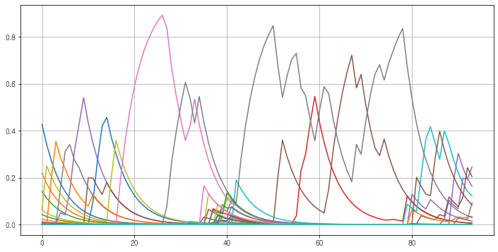

```python
weight_df.plot();
plt.legend().set_visible(False);
```

### Update Peer Group Summary

계산된 변동 weight를 통해 대푯값 업데이트

```python
test_p_i = (weight_df * test_df_normalized[top_k_peers]).sum(axis=1)
test_p_i
```

```
0     1.387050
1     2.011508
2     2.546743
3     3.166244
4     3.094556
        ...
89    3.430631
90    3.217312
91    3.295193
92    3.257558
93    2.969756
Length: 94, dtype: float64
```

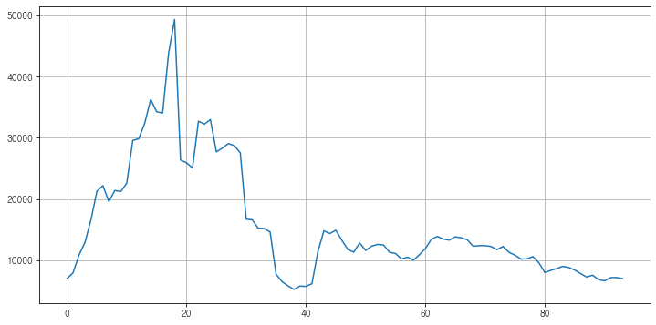

```python
# 종가
test_df_smoothed[target_series.name].plot();
```

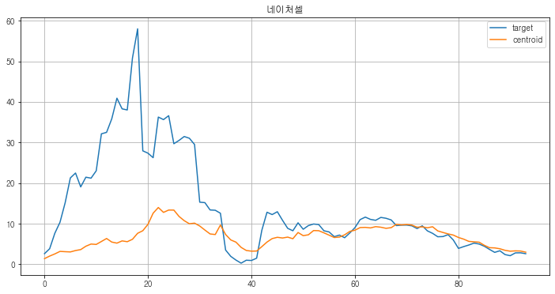

```python
test_target_series.plot(label = 'target');
test_p_i.plot(label = 'centroid');
plt.title(target_series.name)
plt.legend();
```

## Evaluation

그룹의 대푯값 (centroid)를 threshold 범위 이상 벗어날 시 fraud한 종목으로 인식

[figure not shown]

논문에서는 Fraud한 종목에 대한 레이블된 데이터가 있어서 모델 평가를 진행하고 각종 parameter에 대한 sensitivity 분석 등을 진행 (저는 그런 데이터가 없어요...)

다른 종목에 돌린 결과

[figure not shown]